# Regression

```r
sum(df$Loud.Cover)
```

```
## [1] 0
```

In actuality, there are no NA values in Loud.Cover col. But since all the values there are 0, we will not gain much from using it in the prediction model. So we’ll ignore it.

```r
summary(df)
```

```
##  Formatted.Date                    Summary      Precip.Type  Temperature..C.
##  Length:96453       Partly Cloudy      :31733   null:  517   Min.   :-21.822
##  Class :character   Mostly Cloudy      :28094   rain:85224   1st Qu.:  4.689
##  Mode  :character   Overcast           :16597   snow:10712   Median : 12.000
##                     Clear              :10890                Mean   : 11.933
##                     Foggy              : 7148                3rd Qu.: 18.839
##                     Breezy and Overcast:  528                Max.   : 39.906
##                     (Other)            : 1463
##  Apparent.Temperature..C.    Humidity      Wind.Speed..km.h.
##  Min.   :-27.717          Min.   :0.0000   Min.   : 0.000
##  1st Qu.:  2.311          1st Qu.:0.6000   1st Qu.: 5.828
##  Median : 12.000          Median :0.7800   Median : 9.966
##  Mean   : 10.855          Mean   :0.7349   Mean   :10.811
##  3rd Qu.: 18.839          3rd Qu.:0.8900   3rd Qu.:14.136
##  Max.   : 39.344          Max.   :1.0000   Max.   :63.853
##
##  Wind.Bearing..degrees. Visibility..km.   Loud.Cover Pressure..millibars.
##  Min.   :  0.0          Min.   : 0.00   Min.   :0    Min.   :   0
##  1st Qu.:116.0          1st Qu.: 8.34   1st Qu.:0    1st Qu.:1012
##  Median :180.0          Median :10.05   Median :0    Median :1016
##  Mean   :187.5          Mean   :10.35   Mean   :0    Mean   :1003
##  3rd Qu.:290.0          3rd Qu.:14.81   3rd Qu.:0    3rd Qu.:1021
##  Max.   :359.0          Max.   :16.10   Max.   :0    Max.   :1046
##
##  Daily.Summary      Temperature.TempDiff
##  Length:96453       Min.   :-4.811
##  Class :character   1st Qu.: 0.000
##  Mode  :character   Median : 0.000
##                     Mean   : 1.078
##                     3rd Qu.: 2.217
##                     Max.   :10.183
##
```

```r
summary(df$Summary)
```

```
##                              Breezy                      Breezy and Dry
##                                  54                                   1
##                    Breezy and Foggy            Breezy and Mostly Cloudy
##                                  35                                 516
##                 Breezy and Overcast            Breezy and Partly Cloudy
##                                 528                                 386
##                               Clear Dangerously Windy and Partly Cloudy
##                               10890                                   1
##                             Drizzle                                 Dry
##                                  39                                  34
##               Dry and Mostly Cloudy               Dry and Partly Cloudy
##                                  14                                  86
##                               Foggy             Humid and Mostly Cloudy
##                                7148                                  40
##                  Humid and Overcast             Humid and Partly Cloudy
##                                   7                                  17
##                          Light Rain                       Mostly Cloudy
##                                  63                               28094
##                            Overcast                       Partly Cloudy
##                               16597                               31733
##                                Rain                               Windy
##                                  10                                   8
##                       Windy and Dry                     Windy and Foggy
##                                   1                                   4
##             Windy and Mostly Cloudy                  Windy and Overcast
##                                  35                                  45
##             Windy and Partly Cloudy
##                                  67
```

```r
sum(df$Wind.Speed..km.h.==0)
```

```
## [1] 1297
```

It is unlikely that there is absolutely no wind so some of this data may not be accurate.

We’ll pull up some graphs to get a better idea of what we have to do, now. Yellow dots are null precipitation days, green is rain, and blue is snow.

```r
cor(df[4:7])
```

```
##                          Temperature..C. Apparent.Temperature..C.   Humidity
## Temperature..C.              1.000000000                0.9926286 -0.6322547
## Apparent.Temperature..C.     0.992628564                1.0000000 -0.6025710
## Humidity                    -0.632254675               -0.6025710  1.0000000
## Wind.Speed..km.h.            0.008956968               -0.0566497 -0.2249515
##                          Wind.Speed..km.h.
## Temperature..C.                0.008956968
## Apparent.Temperature..C.      -0.056649698
## Humidity                      -0.224951456
## Wind.Speed..km.h.              1.000000000
```

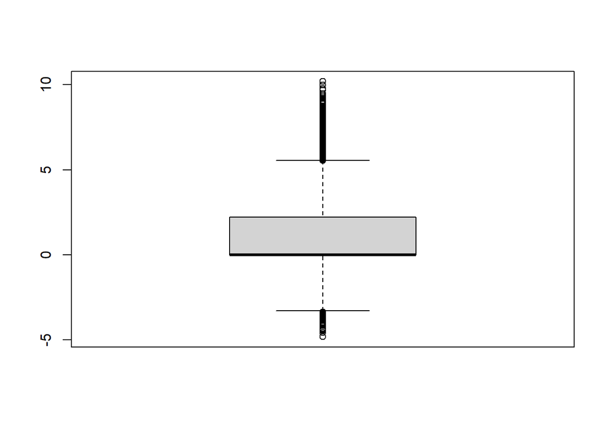

```r
boxplot(df$Temperature.TempDiff)
```

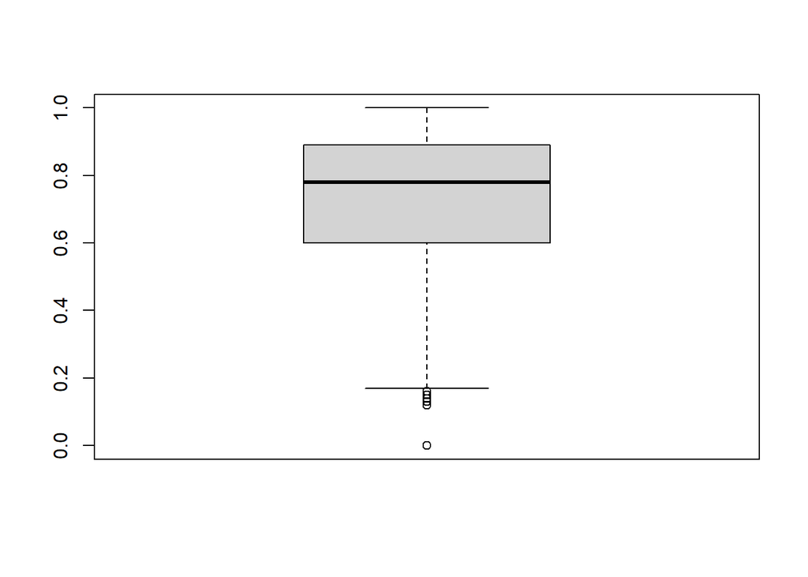

```r
boxplot(df$Humidity)
```

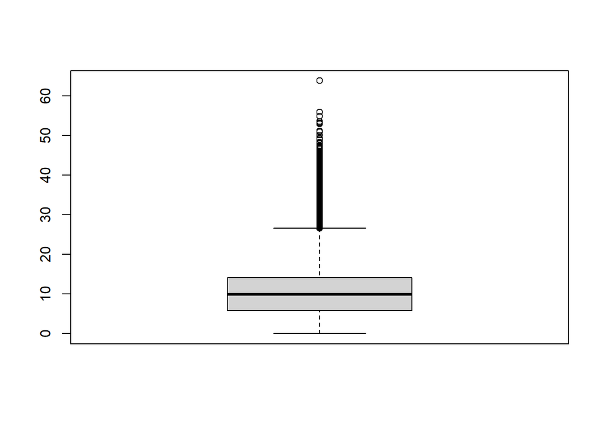

```r
boxplot(df$Wind.Speed..km.h.)
```

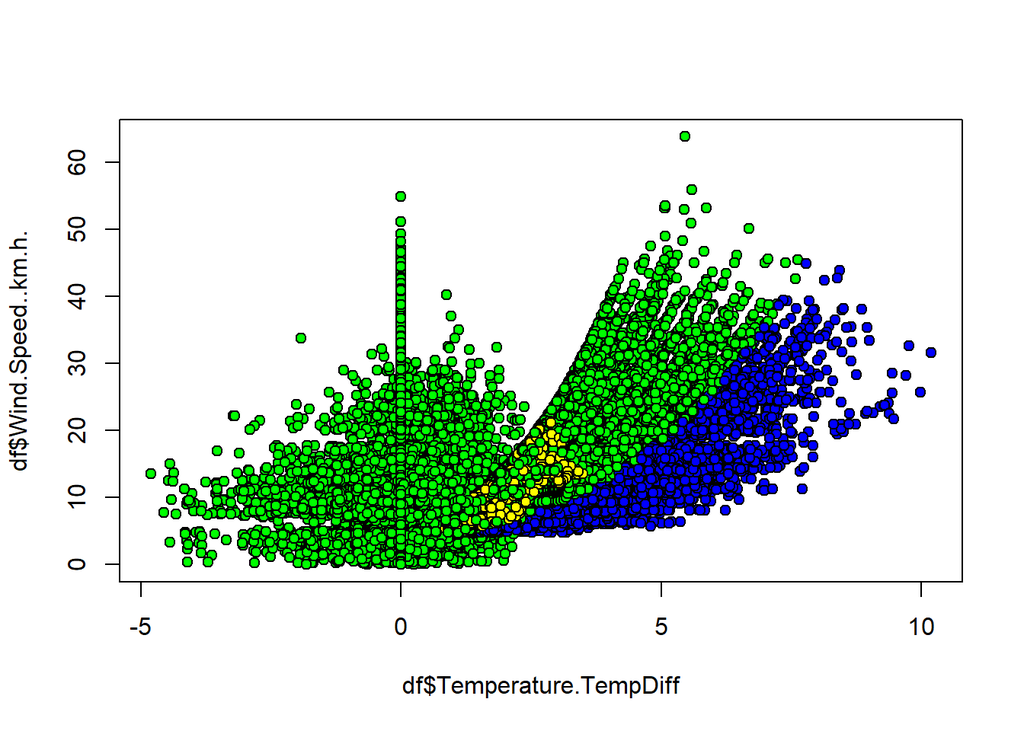

```r
plot(df$Temperature.TempDiff,df$Wind.Speed..km.h.,pch=21,bg=c("yellow","green","blue")[as.integer(df$Precip.Type)])  # lots of 0 values
```

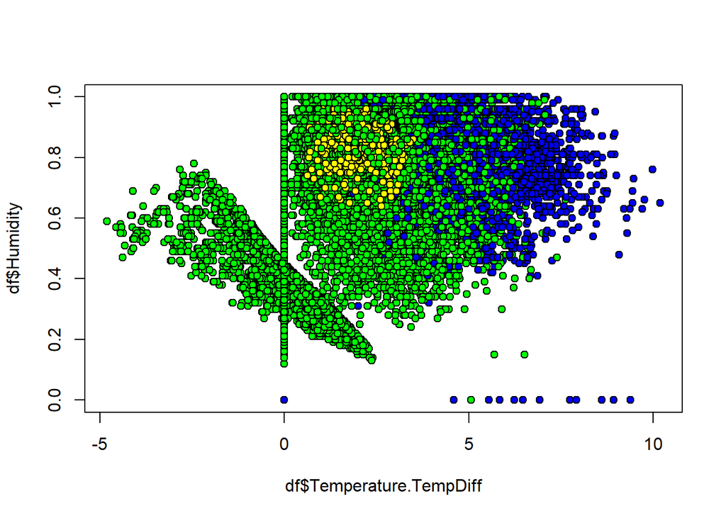

```r
plot(df$Temperature.TempDiff,df$Humidity,pch=21,bg=c("yellow","green","blue")[as.integer(df$Precip.Type)])  # lots of 0 values
```

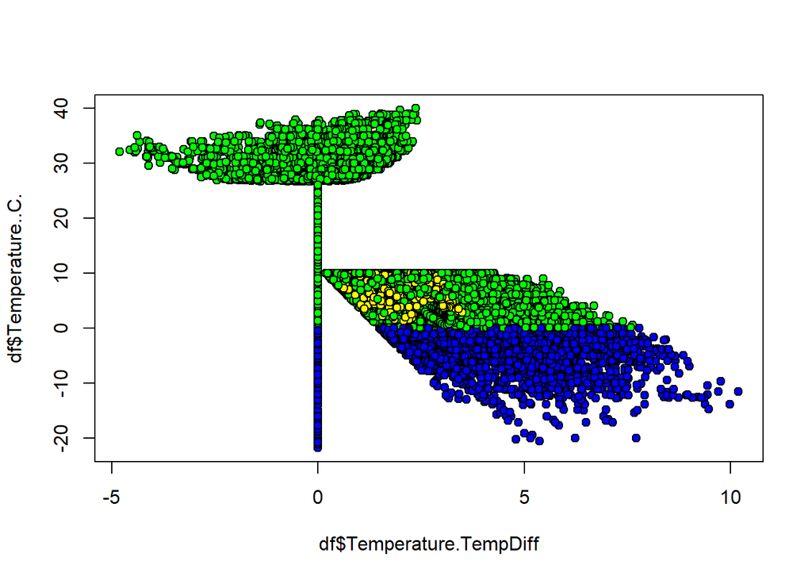

```r
plot(df$Temperature.TempDiff,df$Temperature..C.,pch=21,bg=c("yellow","green","blue")[as.integer(df$Precip.Type)])  # lots of 0 values
```

Now, we’ll clean up the data according to what we found. We’ll clean up only what is referenced, but we will delete what we are uncertain about, since we have such a large amount of data.

```r
df[,6:7][df[,6:7]==0] <- NA  # change 0s to NA values in Humidity and Wind Speed cols
df[,13:13][df[,13:13]==0] <- NA  # change 0s to NA values in TempDiff col
df <- na.omit(df)  # since we have enough data we can omit those which have NA values
summary(df)
```

```
##  Formatted.Date                    Summary      Precip.Type  Temperature..C.
##  Length:40660       Partly Cloudy      :11421   null:  237   Min.   :-20.556
##  Class :character   Mostly Cloudy      :10907   rain:32750   1st Qu.:  1.139
##  Mode  :character   Overcast           : 9062   snow: 7673   Median :  5.122
##                     Clear              : 4167                Mean   :  7.924
##                     Foggy              : 3969                3rd Qu.:  8.867
##                     Breezy and Overcast:  375                Max.   : 39.906
##                     (Other)            :  759
##  Apparent.Temperature..C.    Humidity      Wind.Speed..km.h.
##  Min.   :-27.717          Min.   :0.1300   Min.   : 0.1288
##  1st Qu.: -2.267          1st Qu.:0.6500   1st Qu.: 8.1788
##  Median :  2.544          Median :0.8200   Median :11.2217
##  Mean   :  5.370          Mean   :0.7524   Mean   :12.8271
##  3rd Qu.:  6.839          3rd Qu.:0.9100   3rd Qu.:15.4721
##  Max.   : 39.344          Max.   :1.0000   Max.   :63.8526
##
##  Wind.Bearing..degrees. Visibility..km.    Loud.Cover Pressure..millibars.
##  Min.   :  0.0          Min.   : 0.000   Min.   :0    Min.   :   0
##  1st Qu.:129.0          1st Qu.: 6.311   1st Qu.:0    1st Qu.:1012
##  Median :175.0          Median : 9.982   Median :0    Median :1017
##  Mean   :186.1          Mean   : 9.471   Mean   :0    Mean   :1001
##  3rd Qu.:280.0          3rd Qu.:11.270   3rd Qu.:0    3rd Qu.:1022
##  Max.   :359.0          Max.   :16.100   Max.   :0    Max.   :1046
##
##  Daily.Summary      Temperature.TempDiff
##  Length:40660       Min.   :-4.811
##  Class :character   1st Qu.: 1.483
##  Mode  :character   Median : 2.589
##                     Mean   : 2.554
##                     3rd Qu.: 3.628
##                     Max.   :10.183
##
```

```r
#df_temp <- df
```

Make the graphs again.

```r
cor(df[4:7])
```

```
##                          Temperature..C. Apparent.Temperature..C.    Humidity
## Temperature..C.               1.00000000                0.9957386 -0.78282238
## Apparent.Temperature..C.      0.99573857                1.0000000 -0.75587228
## Humidity                     -0.78282238               -0.7558723  1.00000000
## Wind.Speed..km.h.            -0.08571425               -0.1545778 -0.06160538
##                          Wind.Speed..km.h.
## Temperature..C.                -0.08571425
## Apparent.Temperature..C.       -0.15457779
## Humidity                       -0.06160538
## Wind.Speed..km.h.               1.00000000
```

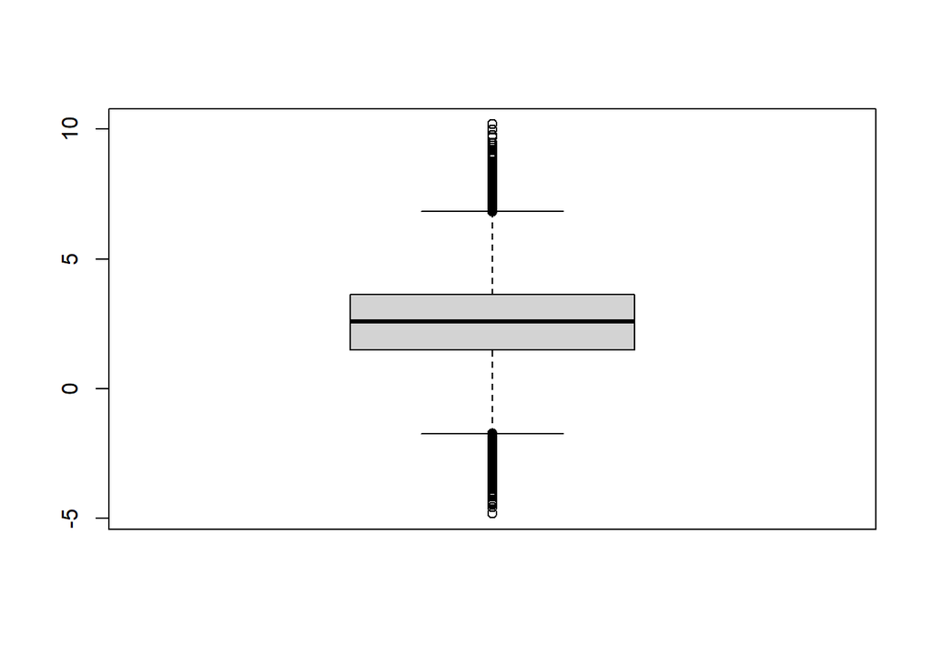

```r
boxplot(df$Temperature.TempDiff)
```

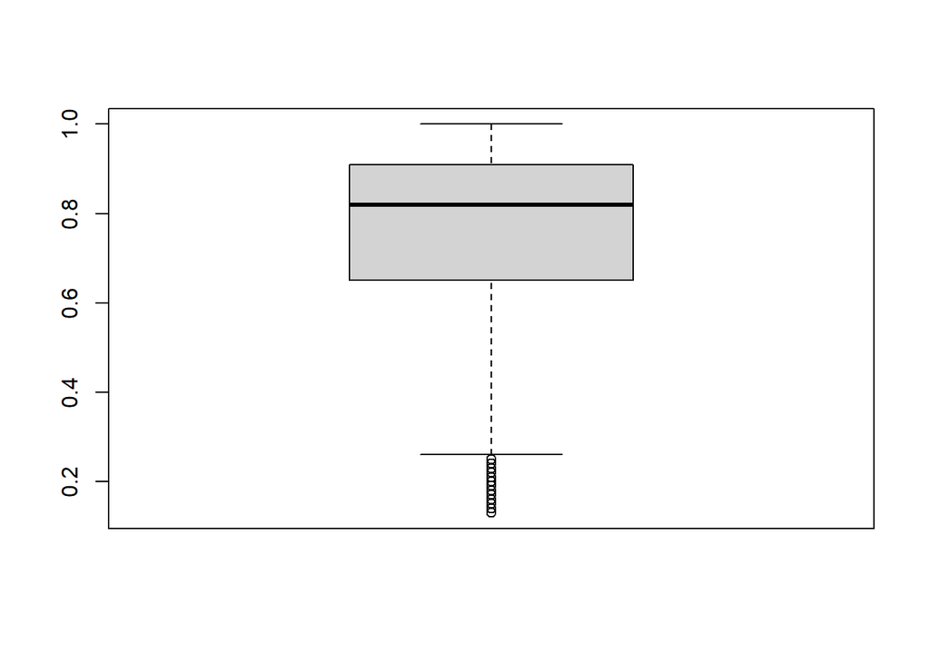

```r
boxplot(df$Humidity)
```